# Coursework Report

*N* removed NAs: 2

*N* removed typo: 1

*N* removed <18: 19

*N* total clean: 128

| Group | *N* | *M*<sub>age</sub> | *M*<sub>rating</sub> |
| --- | --- | --- | --- |
| Control | 62 | 21.1 | 6.16 |
| Experim | 66 | 20.7 | 7.62 |

**Main analysis results**

*t*(126) = -11.92, *p* < .001

[interactive chart not shown]

[figure not shown]

[interactive chart not shown]

# Coursework Report

Analysing Data, Spring 2020

# Methods

## Participants

We initially started off with 150 participants, but due to various reasons we had to remove 22 participants, these reasons included the participants being under the age of 18, another reason was because some of the data wasn’t recorded as numeric data. The mean age of our participants in the control group was 21.11 with the standard deviation being 2.27. The mean age of our participants in the experimental group was 20.70 with the standard deviation being 1.85. The final number of participants we include in our data was 62 in the control and 66 in the experimental bringing the total to 128 participants. We had an age range of 10 years between our youngest and oldest participants

```
## # A tibble: 2 x 4
##   group            n mean_age sd_age
##   <fct>        <int>    <dbl>  <dbl>
## 1 Control         62     21.1   2.27
## 2 Experimental    66     20.7   1.85
```

## Design

Our hypothesis asked whether the colour red has the capacity to have an effect on how attractive a person is perceived to be. Participants were asked to look at one of two pictures in a frame, the control group had a picture of a moderately attractive man within a white frame whilst the experimental group looked at the same picture within a red frame. The participants were asked to give a rating on a 1-9 scale on three questions. We worked out an average from the ratings given from the three questions. This produced our composite score. Colour is our independent categorical variable consisting of two levels (red experimental and white control). The predictor in this experiment was the thing that we manipulated, which was the colour of the frame. Attractiveness was our continuous variable (we measured this on a scale of 1-9 with 9 being considered the most attractive). We will be taking a mean score from each of the questions asked. Our outcome consisted of whether the thing that changes depending our manipulation (whether the rating score changes when we change the colour of the frame). Therefore, we are investigating whether the colour does influence the rating of a moderately attractive man. To measure this, we will be using a t-test.

# Results

Table 2 *A Summary of the general pattern of Results*

[output not shown]

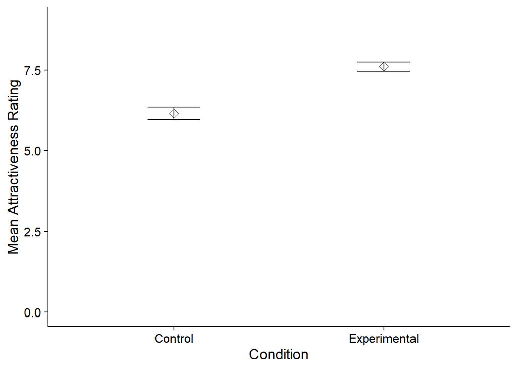

# Discussion

Our results showed us that women in the experimental group (red) compared to the women in the control group (white), found the man shown in the picture to be slightly more attractive in parallelism with the colour red. Thus, supporting the hypothesis that red can influence how attractive people are perceived to be.

In relation to the original study, by Elliot et al, 2010, our results contribute to this area of research as it supports the idea that red can influence how attractive a man is perceived to be by women in conjunction with the colour red. The original study showed us that colour, primarily red can impact the women’s rating of how attractive a man is (Elliot, 2010). Consequently, this idea is further supported by the data that we collected, from our data, we can see that the women’s mean attractive rating in our experimental group was slightly higher, a difference of 1.46. This suggests that the colour red is a factor in how attractive women find men to be, though this reasoning may be unconscious it is still significant. It was also found in the original study that red was used in communication between males and females “conveying important information in subtle, and perhaps even automatic, ways” (Elliot, 2010). Reinforcing the idea that red is a big factor in determining who is attracted to who, even if you are not consciously aware of the factors being you being attracted to another person. Therefore, our study supports the original as both got a higher score for the red condition. The original study also elaborates on the potential reasons why this is the case (the unconscious mechanisms behind finding someone attractive).

In other research, a similar study that looked at how men rated women in regards to the colour red, found that the colour had a huge effect on how the men considered the women to be attractive as well as their sexual attraction to this women, without evening realising that colour had an effect (Lobel, 2016). This shows us again that our unconscious has a huge effect on our decision making. Both in this study and our own study, the colour condition got the higher rating, suggesting that people may not even be aware of all the factors involved when they rate another person in regards to their level of attractiveness. Furthermore, in another study looking at women rating men, it was shown that the colour red has been seen as a symbol of status for humans “Women may presume that healthier, more vital men are also more likely to successfully negotiate the challenges of the status hierarchy and to obtain a high social position” (Peperkoorn, 2016). Therefore, the colour red (this could be an external fixture or perhaps the colour of a man’s cheeks) will potentially increase a man’s attractiveness. Previous work to this has shown that status has been seen as one of the factors that increase a man’s level of attractiveness. In another study, it was suggested that “color effect on attractiveness and sexual desirability was due to the color effect on perceived status” (Francis, 2013). Therefore, by selecting a particular colour, inadvertently men have the opportunity to be perceived as more attractive, as women may believe that choosing a partner of a good status level will be beneficial to them. On the other hand, a study that replicated the original (by Elliot, 2010) found that neither of the two replications that they carried out produced “statistically significant effect of the colour red on the dependent variable” (Hesslinger, 2015). This suggests that the red effect may not be as strong as we were led to believe from the multiple experiments carried out by Elliot. When looking at the replicability of the red-attractiveness effect, it was argued that “research by independent laboratories further supports and extends the red-attractiveness effect for women viewing men” (Elliot and Maier, 2013). Thus, suggesting that the research since the original study (Elliot, 2010) has added value to this area of research. As the results seem to suggest that there is a link between the colour red and how attractive a person is perceived to be, though the strength of the link between the two is still needs further investigation.

One of our advantages include the way in which we collected the responses (rating scales). The advantages of using rating scales is that they’re easy to administer and score and they measure a specified outcome (in this case how attractive someone is perceived to be). As well as, the research method (experiment) meant that we were able to control the situation in which participants viewed the picture and this allowed us to establish the cause and effect (whether red really does make someone more attractive). Moreover, the researcher has control over the variables, meaning that there is a higher chance of determining the individual effects of each variable as well as the interaction between them. Whilst our limitations consist of sample being made up of university students, this makes it harder to generalise results to the wider population as sample is unlikely to be representative of the whole population. To further add to the idea that the results might not be generalisable, the studies only looked at heterosexual people, to be able to see if this a universal effect for different sexual preferences. As well as the situation would be artificial, as most people wouldn’t rate someone’s attractiveness in a photo, they would look at the person in real life. Finally, it could be argued that the results to a certain degree are artificial, as variables are being manipulated so the experiment measures what the researchers want it to (that there is a link between attraction and red). Overall, I believe that there is strong chance that red can influence whether a person is rated as attractive or not. However, there is doubts in regards to how strong this link is and this would need further investigation to ensure that red is indeed a factor in being perceived as attractive.

I believe that there will be a need for a follow up study. The results from our study and the original has highlighted a link between the colour of red and being rated as attractive, however we should consider the strength of this link. The factors that make someone attractive are still under investigation and we need to better understand the unconscious reaction to finding someone attractive. For example, we could use continuous flash suppression, where one eye is presented with a static stimulus (picture of a man in red frame) and the other eye is presented with a rapidly changing stimuli (different colour frames). By using this method, we would have a better understanding of preconscious mechanisms in relation to visual perception to see if a person is drawn to the red frame over the other colours. Another improvement we could make is that a lot of the previous evidence we have seen has come from a person wearing an external feature in red or being placed in a red frame. We know from studies looking at animals that the males will often display red when looking for a female partner, if we compared humans in regard to their skin being flushed or not, we would be able to determine whether this is a primitive feature in what makes someone attracted to another person or not. Finally, once we have established the previously stated improvements, what we would need to do is to run another study so that we can improve the generalisability of the results. The sample of our study (as well as primarily the other studies in this area) was university students (not the biggest sample sizes) and this means that we may not be able to rely on the results that are obtained. In a different study that didn’t find supporting evidence for the red effect in relation to how attractive a person is perceived to be (Peperkoorn, 2016), they also suggested a bigger sample was needed in order to be sure whether there was a link or not. Therefore, a bigger sample size would be needed that is made up of a more diverse sample, to better reflect the population, so that results are more reliable and valid. With this we are in a better position to generalise results to the wider population and make a suggestion to whether females really do find men more attractive in conjunction with the colour red.

In conclusion, we did find evidence supporting the original study that there is a link between the colour red and being perceived as being more attractive. However, the strength of this link is still up for debate. Once we have established this link, we would be in a better position to say for certain whether red does actually make someone more attractive or not.

# References

“Elliot, A. J., & Maier, M. A. (2013). The red-attractiveness effect, applying the ioannidis and trikalinos (2007b) test, and the broader scientific context: A reply to francis (2013). Journal of Experimental Psychology: General, 142(1), 297-300. doi:http://dx.doi.org/10.1037/a0029592 Francis, G. (2013). Publication bias in “Red, rank, and romance in women viewing men,” by elliot et al. (2010). Journal of Experimental Psychology: General, 142(1), 292-296.

doi:http://dx.doi.org/10.1037/a0027923 Hesslinger, V.M., Goldbach, L. & Carbon, C. Men in red: A reexamination of the red-attractiveness effect. Psychon Bull Rev 22, 1142–1148 (2015). https://doi.org/10.3758/s13423-015-0866-8 Lobe, T. (2016). Sensation: the new science of physical intelligence. Atria Paperback, 65-82. Peperkoorn, L. S., Roberts, S. C., & Pollet, T. V. (2016). Revisiting the Red Effect on Attractiveness and Sexual Receptivity: No Effect of the Color Red on Human Mate Preferences. Evolutionary Psychology. https://doi.org/10.1177/1474704916673841